# Chapter3

2016年8月7日

## Graphics

I’m no mathematician, so I’m stuck with the graphic representations.  
– Hugh Hopper, Musician.

## 3.1 Who should read this chapter?

Simply put, everyone should read this chapter.  
A good graph is almost better than any statistical analysis. Drawing a good graph is a skill.  
This chapter covers good and bad habits in drawing a graph and explains how R can be used to make high-quality publication ready graphs.

## 3.2 Introduction

In this chapter we will discuss a little bit of the philosophy behind creating graphical representations of data and the practical side of producing high quality statistical graphics.

By “high quality” I mean graphics that are suitable for publication.

## 3.2.1 A little bit of language

In this chapter I will use the words drawing, graph, (statistical) graphic, and plot interchangeably.

I will not use the word chart, which has strong associations with MicrosoftR ExcelR.

## 3.3 Why are we doing this?

A fundamental question I think many scientists fail to ask themselves is “Why am I drawing this graph?”

The answer should be “Because I want the reader or the audience to be able to easily understand the point that I am making with this data.”

We approach this section with that purpose in mind—to be able to produce the graph that best displays to the intended audience the information or point we want to make.

## 3.4 Flexible versus “canned”

Software systems that produce graphics generally come in two flavors that I like to call “flexible” and “canned.”

A useful compromise is to offer the “canned” graphs as a simple default, but to provide the flexibility behind the scenes. This is the way that R and many other statistical software packages work.

## 3.5 Drawing simple graphs

The form or type of the data can guide us in our choice of the most appropriate plot.

We will primarily discuss grouped data or data sets with two or more variables.

## 3.5.1.1 The bar plot

The bar plot is used to represent frequency table or count table data.

As the name suggests, a bar plot consists of a series of bars, which may be displayed horizontally or vertically.

There is (usually) one bar for each category, and the heights or lengths of the bars are proportional to the sample frequencies of counts falling into each category. The widths of the bar plot have no meaning, and there are usually gaps between the bars.

## 3.5.2 The histogram

The histogram is used to show the distributional shape of a continuous variable.

The heights and the widths of the bars are important because the area contained in the bars, and not height, is used to represent the frequency of the observations falling into each class interval.

Some software packages use the bar plot routine to produce both bar plots and histograms, which occasionally leads to poor plots.

## 3.5.3 Kernel density estimates

A kernel density estimate (KDE) is used to show the distributional shape of a continuous variable.

It can be regarded as a smoothed histogram.

## 3.5.4Box plots

Box plots or box and whisker plots can be a good tool for quickly comparing grouped data with respect to a continuous variable. Box plots provide a visual display of a set of summary statistics.

Box plots are good for getting a quick overview of the positions and spreads of grouped data. However, box plots are not sensible when there are relatively few observations per group

## 3.5.4

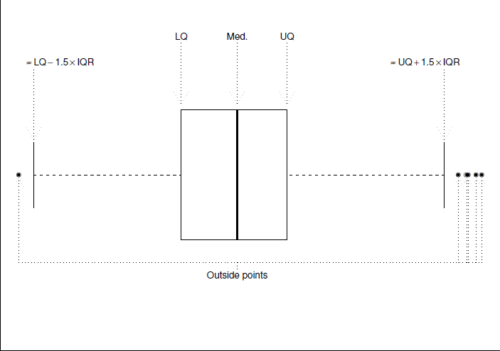

## 3.5.5 Scatter plots

Scatter plots, perhaps the most familiar type, are useful when we have two quantitative variables.

The scale of the horizontal axis represents the range of one variable and the scale of the vertical axis represents the range of the others.

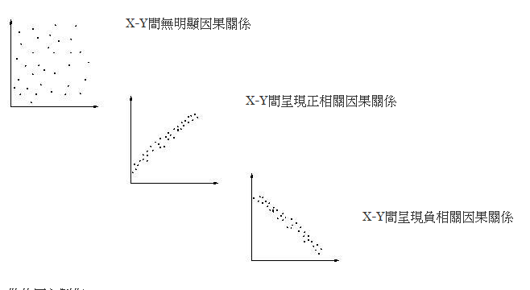

## 3.5.6 Plotting categorical data

The primary tool for plotting categorical data is the bar plot.

A plot showing the categories in decreasing order and with a cumulative frequency line is sometimes called a Pareto chart. A Pareto chart is used to identify the most important (or largest) categories.

The bar proportions make it easier to read the contributions of the very small categories to the total.

## 3.5.6

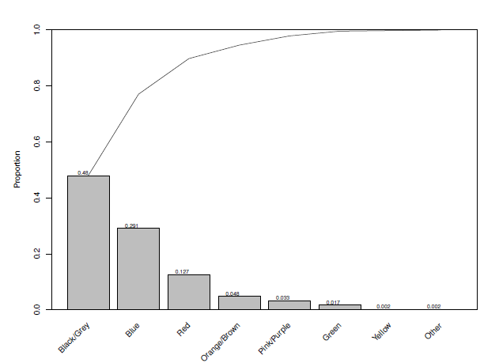

## 3.5.6.1 Plotting groups

One situation where bar plots can be useful is comparing proportions between groups.

There is a limit to this, however, in that the plots are only sensible when the number of categories within each group or number of groups is relatively low. That is, if you have more than five to six groups or more than four or five categories to compare, then a bar plot may not be sensible.

## 3.5.6.1

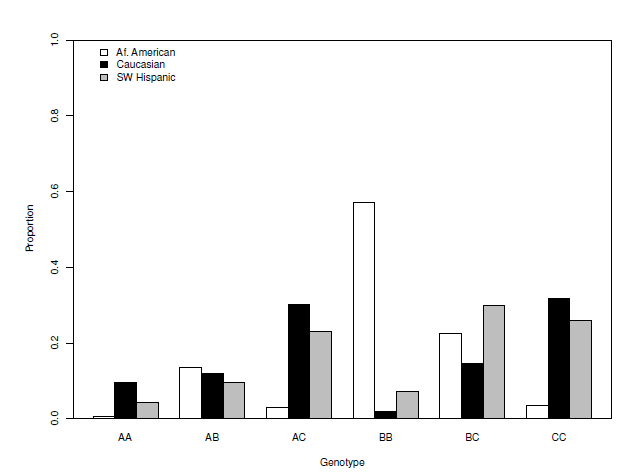

## 3.5.6.2 Pie graphs, perspective, and other distractions

My aim throughout this book is to emphasize good practice and not spend an excessive amount time criticizing the things I regard as bad practice. For this reason I have shown you how I think simple categorical data should be displayed with bar plots and not with pie graphs. In this section I will cover some of what I consider bad practice and the reasons.

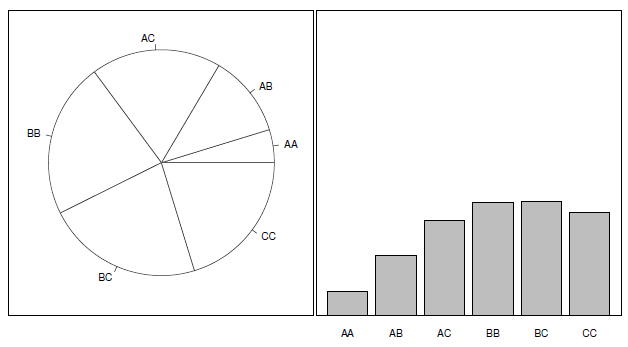

## 3.5.6.2 Pie graphs, perspective, and other distractions

Pie graphs are commonly used in the scientific literature and the popular press when the data being displayed are proportions or percentages (of a whole).

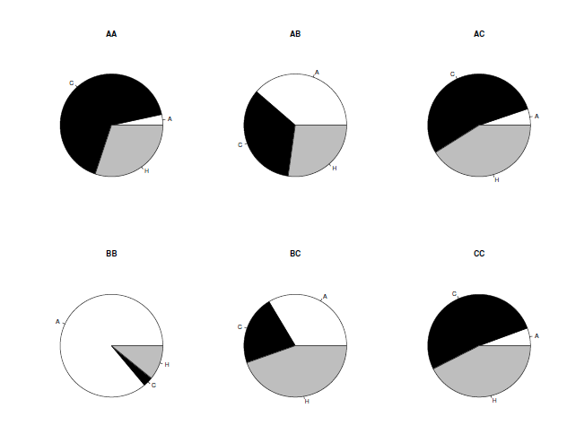

## 3.5.6.2 Pie graphs, perspective, and other distractions

Stacked bar plots are a commonly used method of displaying grouped information on a single bar plot.

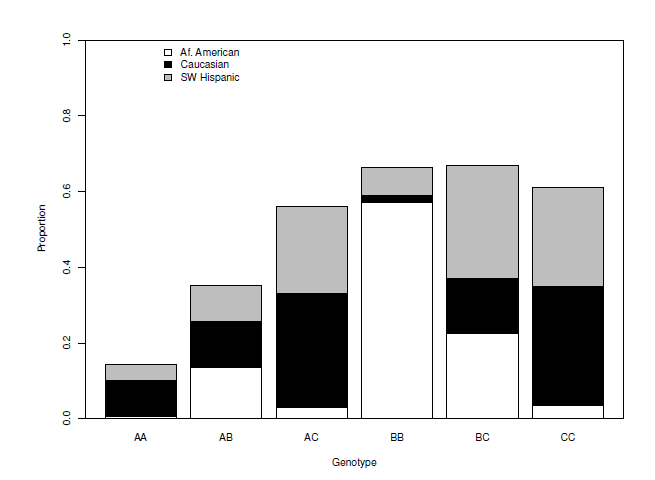

## 3.5.7 One categorical and one continuous variable

In this situation we are concerned with the graphical display of the differences (or similarities) in groups of observations with respect to a continuous variable.  
The way we choose to display this information can depend on the number of observations per group and potentially the number of groups.  
The tools we will use are the scatter plot, the histogram, the kernel density estimate, and the box plot.

## 3.5.7 One categorical and one continuous variable

You can then plot the group number on the x-axis and the continuous variable on the y-axis. This plot is useful for getting an initial feel for the data; however, it tells us very little about distributional shape.

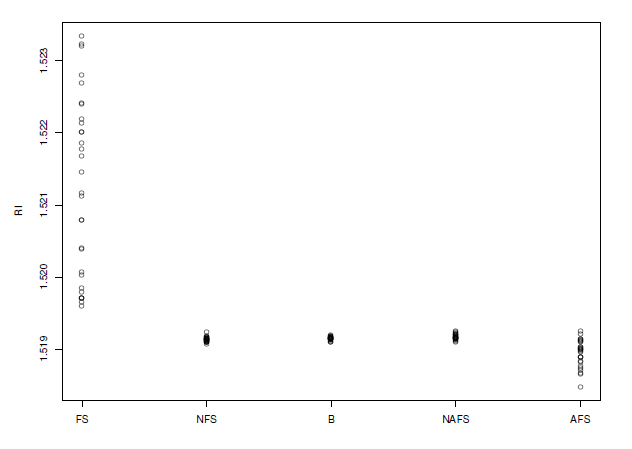

## 3.5.7.1 Comparing distributional shape

Comparing distributional shape between grouped data can be moderately difficult even for small numbers of groups. Our tools for assessing distributional shape are the histogram, the kernel density estimate, and to some extent box plots.

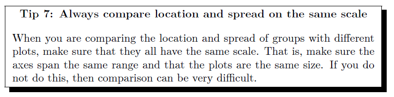

## 3.5.7.1 Comparing distributional shape

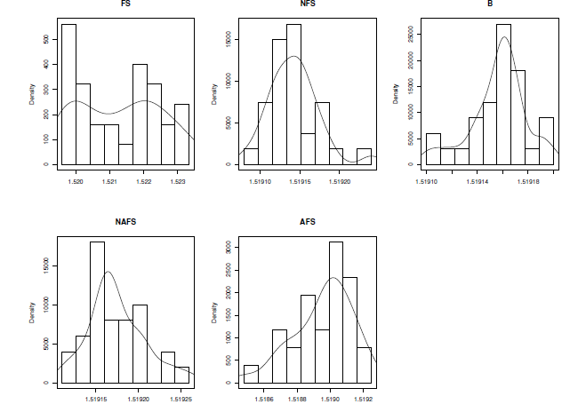

## 3.5.7.1 Comparing distributional shape

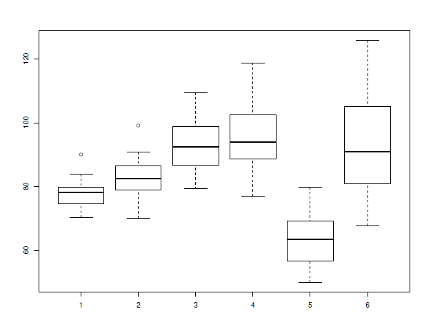

## 3.5.8 Two quantitative variables

There are three possibilities when we have two quantitative variables: two discrete, one discrete and one continuous, and two continuous.

If you have two discrete variables that do not show much variation, then it may be the case that no plot is going to shed light on the data.

## 3.5.8 Two quantitative variables

If both variables are discrete with lots of possible values, or both variables are continuous, then we will get a traditional scatter plot.

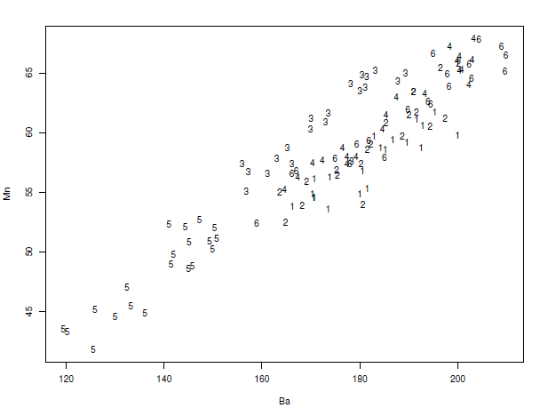

## 3.5.8 Two quantitative variables

If one of the variables is discrete and has few values, then the plot will look something like Figure.

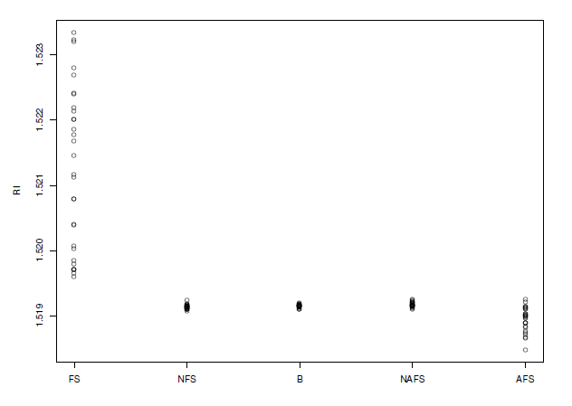

## 3.6 Annotating and embellishing plots

There are a number of small things that we can add to plots to make them more informative. Note my choice of words there, however: “…to make them more informative.”  
If our additions do not improve the understanding of our plots, then we should remove them.

## 3.6.1 Legends

Adding a legend to a plot can be useful when we are displaying information about multiple groups or cases.  
If you add a legend to a plot, make sure that the legend labels are informative but concise, and that the size of the legend does not lead to its dominating the plot itself.

## 3.6.2 Lines and smoothers

Straight lines and smoothing lines can be a good addition to a scatter plot of two quantitative variables.

We may add a straight line to a plot to show how well, or not, the data conform to a linear trend. A “smoothing” line may be sensible if the data follow a trend that is not well described by a straight line.

## 3.6.3 Text and point highlighting

The addition of text to a plot can be helpful in certain circumstances.  
Firstly, we might consider labeling individual points on a plot. Situations where this might be useful are if we want to highlight a set of extreme points or perhaps a particular group of observations.  
Secondly, we might want to add text to a plot when we have used a model to describe the data.

## 3.6.4 Color

- The addition of color to a plot can be very helpful.
- -Can the colors I use be easily distinguished from each other and from the background?
- -Do the colors still make sense if my article or report is printed in grayscale?
- -Do the colors that I have used on the screen look the same when I print them out?

## 3.6.5 Arrows, circles, and everything else

We can add anything we like to a plot. For example, if we are showing a statistical clustering technique, then we might circle a set of points with a circle or an ellipse.  
Arrows can be used to point to certain features with a text label.  
At the end of the day, we must return to our question “Does it help us explain the data or make our point?”

## 3.7 R graphics tutorial

```r
install.packages("dafs", repos = "http://cran.r-project.org")
library(dafs)
```

## 3.7.1 Drawing bar plots

1.Load the FBI-Gc data.  
2. Create a table of counts for the genotypes and print it out.

## 3.7.1 Drawing bar plots

```r
data(gc.df)
tbl = table(gc.df$genotype)
tbl
```

```
##
##  AA  AB  AC  BB  BC  CC
##  29  72 114 136 137 124
```

## 3.7.1 Drawing bar plots

1. Turn the table into a table of proportions by dividing by the table sum.

## 3.7.1 Drawing bar plots

```r
tbl = tbl/sum(tbl)
tbl
```

```
##
##         AA         AB         AC         BB         BC         CC
## 0.04738562 0.11764706 0.18627451 0.22222222 0.22385621 0.20261438
```

## 3.7.1 Drawing bar plots

1. Create a bar plot

## 3.7.1 Drawing bar plots

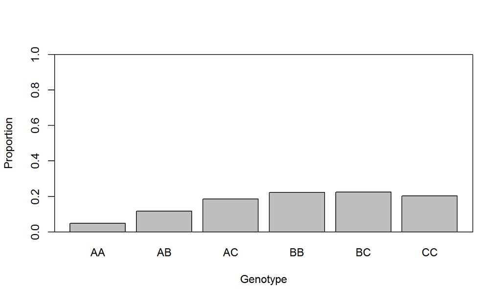

```r
barplot(tbl, ylim = c(0, 1), xlab = "Genotype",
ylab = "Proportion")
box()
```

## 3.7.1 Drawing bar plots

Add the cumulative frequency line to the bar plot.

## 3.7.1 Drawing bar plots

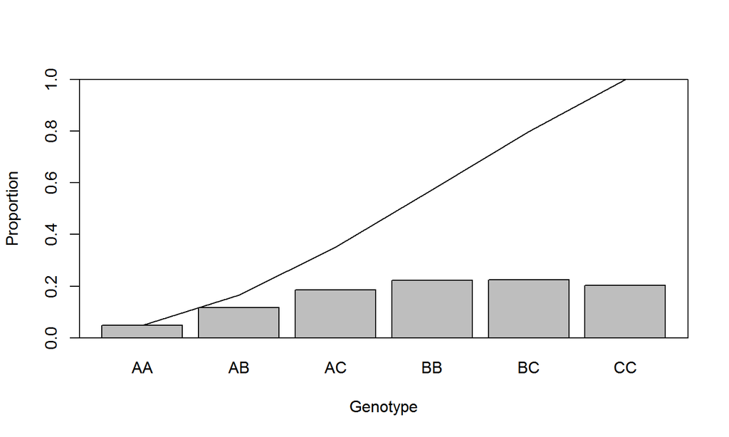

```r
midpts = barplot(tbl, ylim = c(0, 1), xlab = "Genotype",
ylab = "Proportion")
cumppn = cumsum(tbl)
lines(midpts, cumppn)
box()
```

## 3.7.1 Drawing bar plots

Put the proportions (to two decimal places) on the top of each bar.

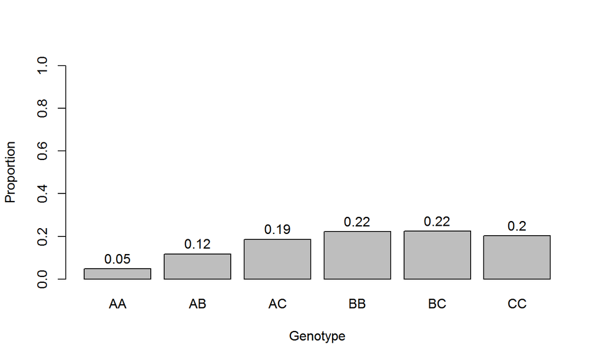

```r
midpts = barplot(tbl, ylim = c(0, 1), xlab = "Genotype",ylab = "Proportion")
text(midpts, tbl + 0.05, round(tbl, 2))
```

## 3.7.1 Drawing bar plots

To produce a bar plot for grouped data, we need a table (or a matrix), where there is a row for each group.

```r
tbl = table(gc.df$racecode, gc.df$genotype)
tbl
```

```
##
##      AA  AB  AC  BB  BC  CC
##   A   1  28   6 117  46   7
##   C  19  24  60   4  29  63
##   H   9  20  48  15  62  54
```

## 3.7.1 Drawing bar plots

The code below shows how we could make the same table with xtabs. I have included it here for completeness.

```r
tbl1 = xtabs(~racecode + genotype, data = gc.df)
tbl1
```

```
##         genotype
## racecode  AA  AB  AC  BB  BC  CC
##        A   1  28   6 117  46   7
##        C  19  24  60   4  29  63
##        H   9  20  48  15  62  54
```

## 3.7.1 Drawing bar plots

Next, we want to convert the rows of this table into the row proportions.  
To do this we need the row sums, which can be obtained with the rowSums command.

## 3.7.1 Drawing bar plots

```r
rowSums(tbl)
```

```
##   A   C   H
## 205 199 208
```

```r
tbl = tbl/rowSums(tbl)
round(tbl,4)
```

```
##
##         AA     AB     AC     BB     BC     CC
##   A 0.0049 0.1366 0.0293 0.5707 0.2244 0.0341
##   C 0.0955 0.1206 0.3015 0.0201 0.1457 0.3166
##   H 0.0433 0.0962 0.2308 0.0721 0.2981 0.2596
```

## 3.7.1 Drawing bar plots

Now we have the information we need to plot the proportions by race code.

## 3.7.1 Drawing bar plots

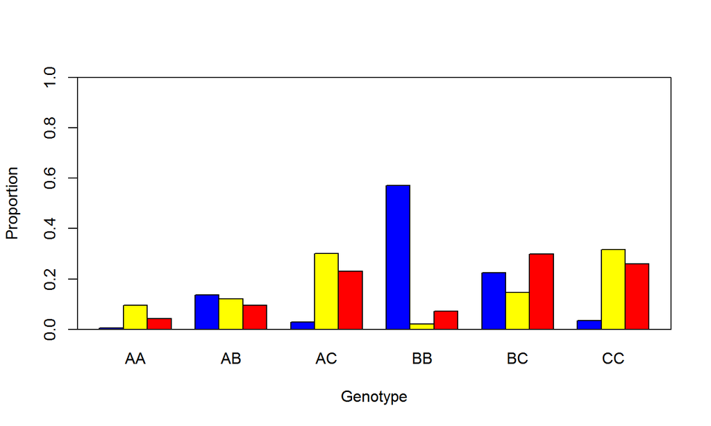

```r
barplot(tbl, beside = T, ylim = c(0,1),
xlab = "Genotype", ylab = "Proportion",
col = c("blue", "yellow", "red"))
box()
```

## 3.7.1 Drawing bar plots

Add a legend to the plot, showing how the colors relate to the race code.

## 3.7.1 Drawing bar plots

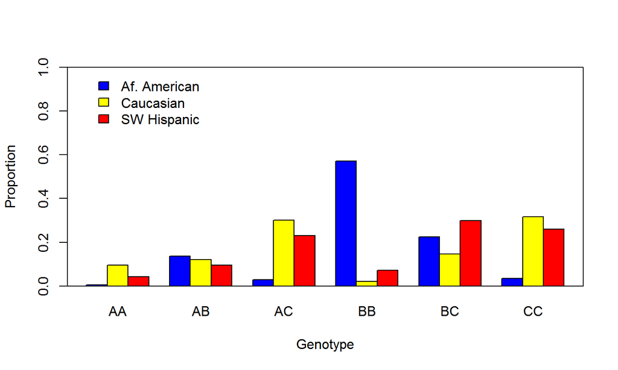

```r
barplot(tbl, beside = T, ylim = c(0,1),xlab = "Genotype", ylab = "Proportion",col = c("blue", "yellow", "red"))
legend(1,0.99,
legend = c("Af. American", "Caucasian","SW Hispanic"),col = "black",fill = c("blue", "yellow", "red"), bty ="n")
box()
```

## 3.7.2 Drawing histograms and kernel density estimates

1. Load the RI data from Bennett et al

```r
data(bennett.df)
```

we can use the unlist command to collapse the data into a single vector, which we will call ri.

```r
ri = unlist(bennett.df)
ri
```

[output not shown]

[output cut: 69 more lines]

[output not shown]

## 3.7.2 Drawing histograms and kernel density estimates

The hist command produces a histogram.

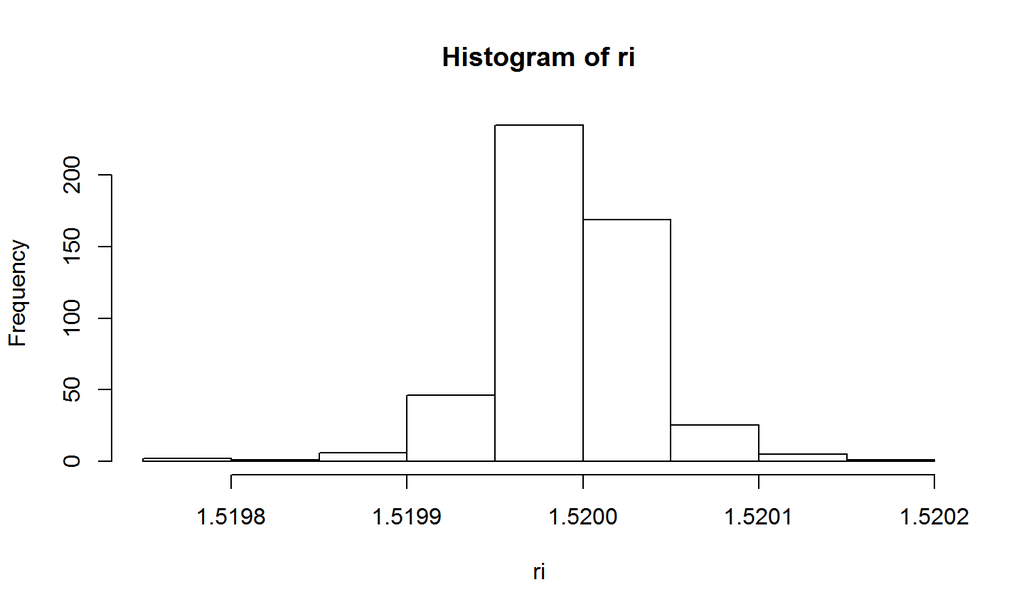

```r
hist(ri)
```

## 3.7.2 Drawing histograms and kernel density estimates

The density command creates a density estimate, but it does not actually draw it. To plot the density estimate,you need to use the plot command.

## 3.7.2 Drawing histograms and kernel density estimates

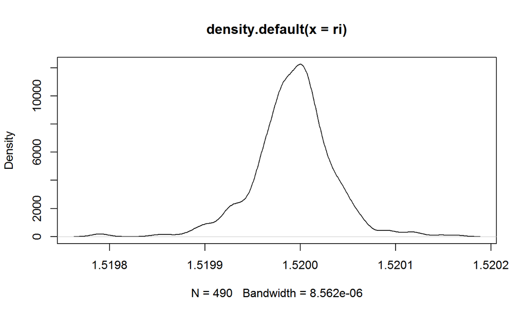

```r
plot(density(ri))
```

## 3.7.2 Drawing histograms and kernel density estimates

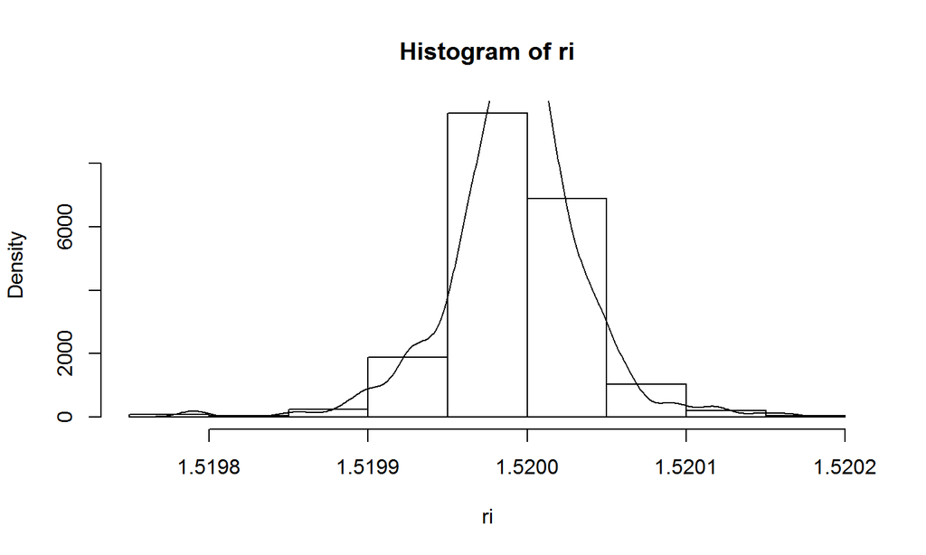

```r
hist(ri, prob = T)
lines(density(ri))
```

## 3.7.2 Drawing histograms and kernel density estimates

You will notice that the density estimate curve touches the top of the plot.We need to change the limits of the y-axis.

## 3.7.2 Drawing histograms and kernel density estimates

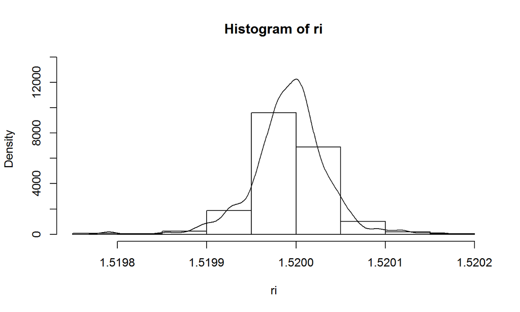

```r
d = density(ri)
yMax = max(d$y) * 1.1
hist(ri, prob = T, ylim = c(0, yMax))
lines(d)
```

## 3.7.2 Drawing histograms and kernel density estimates

Finally, we will clean up our plot a little bit and make it nicer. We will: ‧ change the x-axis label; ‧ remove the graph title; ‧ make the histogram a little more fine scale, i.e., use smaller width bars; ‧ make the x-axis touch the bottom of the histogram; and ‧ make the density estimate line width thicker

## 3.7.2 Drawing histograms and kernel density estimates

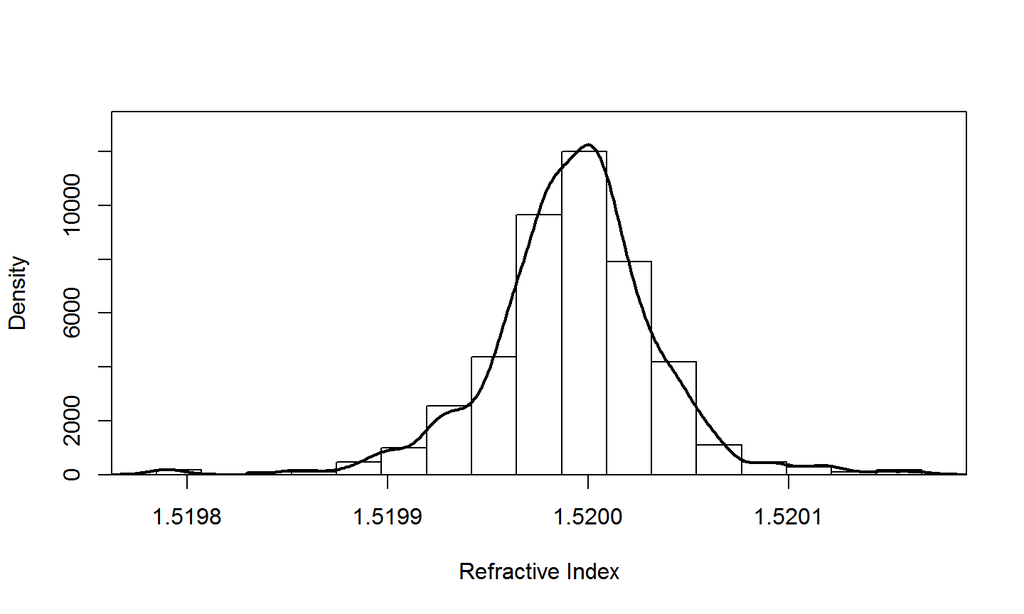

```r
par(xaxs = "i", yaxs = "i")
d = density(ri)
yMax = max(d$y)*1.1
breaks = seq(min(d$x),max(d$x),length = 20)
hist(ri, prob = T, ylim = c(0, yMax),xlab = "Refractive Index",main = "", breaks = breaks)
lines(d, lwd = 2)
box()
```

## 3.7.3 Drawing box plots

Load the Bennett data set.

```r
data(bennett.df)
```

## 3.7.3 Drawing box plots

Produce a box plot of the first 10 groups.

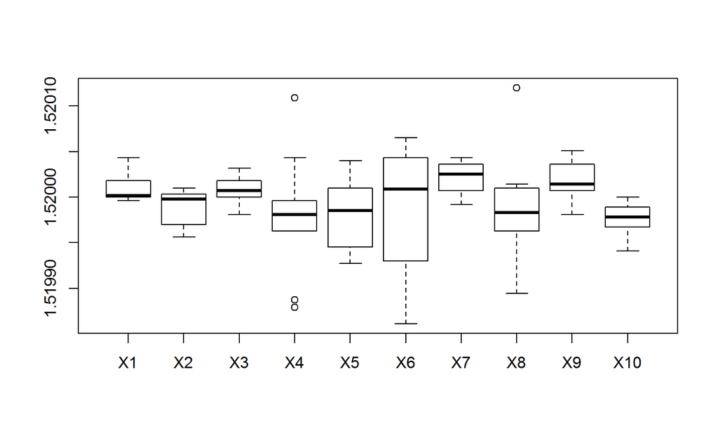

```r
boxplot(bennett.df[, 1:10])
```

## 3.7.3 Drawing box plots

Create a box plot of the zirconium concentration of the different bottles.

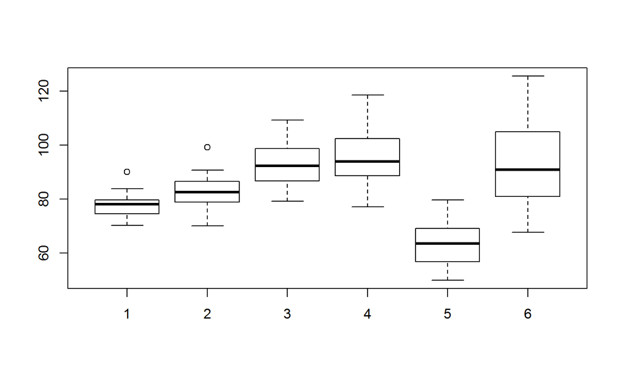

```r
data(bottle.df)
boxplot(Zr ~ Number, data = bottle.df)
```

## 3.7.3 Drawing box plots

Add the actual data points to the box plot. Use the plotting symbol "x".

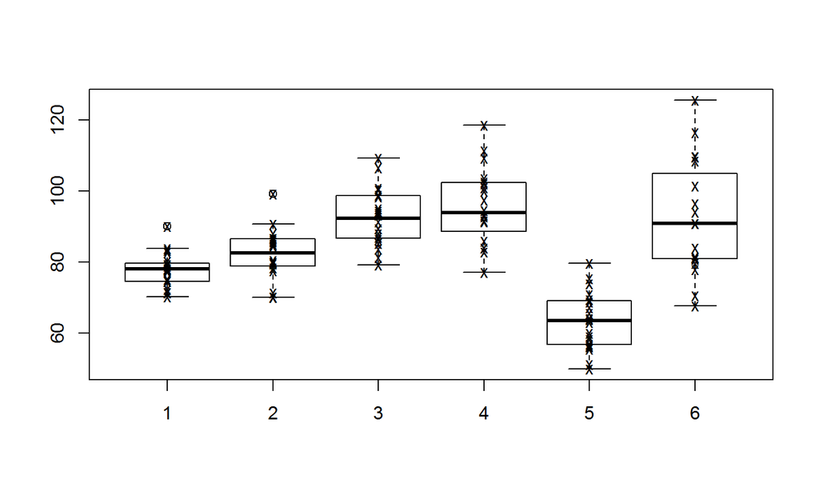

```r
boxplot(Zr ~ Number, data = bottle.df)
points(bottle.df$Number, bottle.df$Zr, pch = "x")
```

## 3.7.4 Drawing scatter plots

The simplest way to use plot is plot(x,y), where x is a set of x-values and y is a y-values. plot will draw a set of points at (x1, y1), (x2, y2)

## 3.7.4 Drawing scatter plots

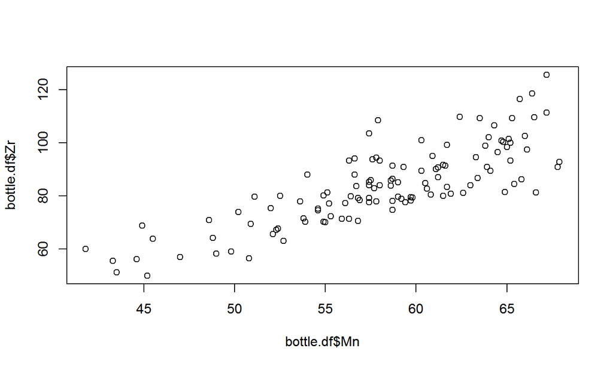

```r
data(bottle.df)
plot(bottle.df$Mn, bottle.df$Zr)
```

## 3.7.4 Drawing scatter plots

There is an alternative syntax that can be quite useful when your data are stored in a data frame.

## 3.7.4 Drawing scatter plots

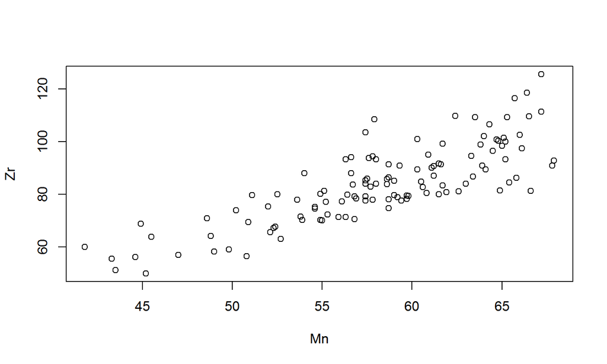

```r
plot(Zr ~ Mn, data = bottle.df)
```

## 3.7.4 Drawing scatter plots

As we noted previously, it can be helpful to add a straight line or a smoothing line to a plot.

## 3.7.4 Drawing scatter plots

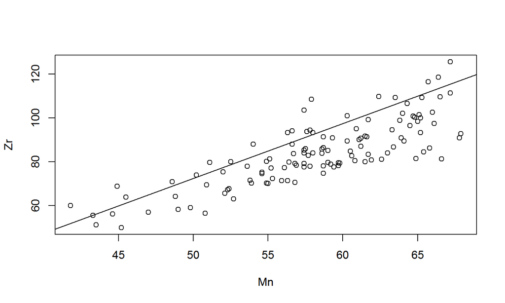

```r
plot(Zr~Mn, data = bottle.df)
# draw a line with intercept = -52.5 and slope = 2.5
abline(c(-52.5,2.5))
```

## 3.7.4 Drawing scatter plots

If you do not know the intercept and the slope, but want them estimated from the data.  
The lm function will find the best least squares fit to the data; more on this in later chapters

## 3.7.4 Drawing scatter plots

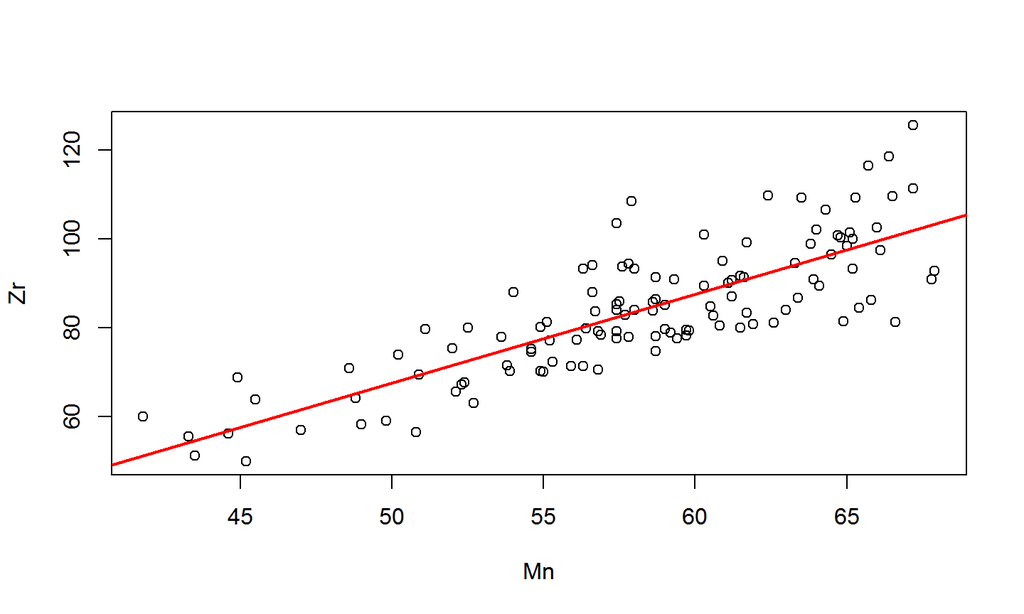

```r
plot(Zr~Mn, data = bottle.df)
fit = lm(Zr~Mn, data = bottle.df)
abline(fit, col = "red", lwd = 2)
```

## 3.7.4 Drawing scatter plots

To add a smoothing line, we have two possible functions and they both work slightly differently, although they produce similar lines. The command lowess takes x- and y-values as its argument and produces a set of x- and y-values that can be used in the lines function.

## 3.7.4 Drawing scatter plots

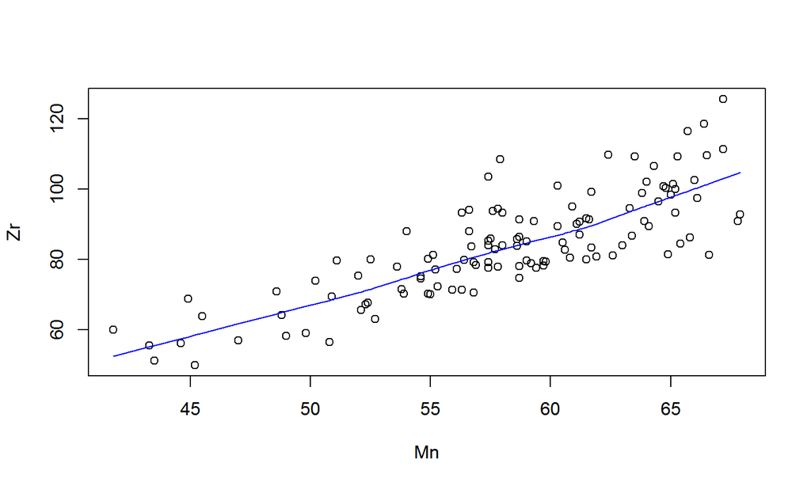

```r
plot(Zr ~ Mn, data = bottle.df)
lines(lowess(bottle.df$Mn, bottle.df$Zr), col = "blue")
```

## 3.7.4 Drawing scatter plots

The loess function takes a formula in the same way that plot does. However, in order to plot the line, it is necessary either for the x-values to be sorted into order, or for some ordering to take part in the plotting. For example,

## 3.7.4 Drawing scatter plots

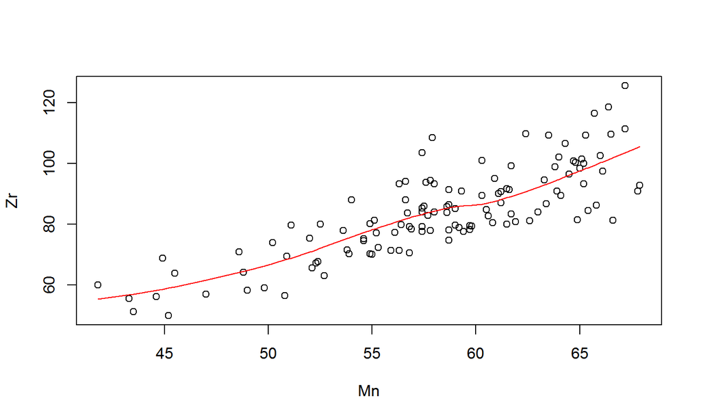

```r
plot(Zr ~ Mn, data = bottle.df)
# first we create the smoothed line
loessLine = loess(Zr~Mn, data = bottle.df)
# then we find out the order of the x values
o = order(bottle.df$Mn)
# then we plot the line (segments) in order
lines(loessLine$x[o], fitted(loessLine)[o], col = "red")
```

## 3.7.4 Drawing scatter plots

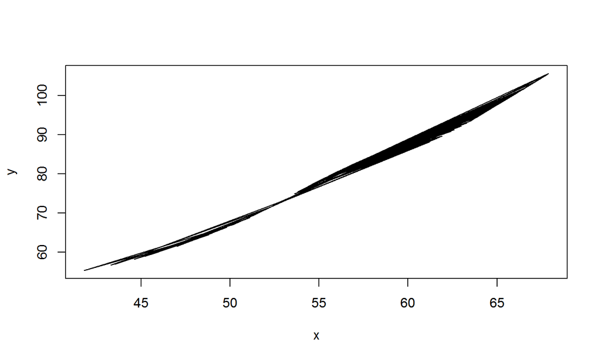

```r
loessLine = loess(Zr~Mn, data = bottle.df)
o = order(bottle.df$Mn)
x = loessLine$x
y = fitted(loessLine)
# without ordering first
plot(x,y,type = "l")
```

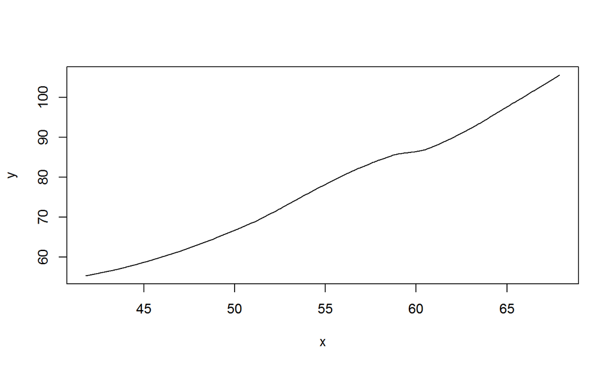

```r
# with ordering
x = x[o]
y = y[o]
plot(x,y,type = "l")
```

## 3.7.5 Getting your graph out of R and into another program

Producing graphs in R is all very well, but most of us produce a graph because we want to show something in a presentation, a research article, or a book.  
If you are planning to take an R graphic and put it into MicrosoftR WordR or MicrosoftR PowerPointR, the simplest thing you can do is right click on the graph after you have drawn it. This will bring up the context menu shown in Figure 3.16. Select “Copy as metafile” from this menu and then paste the image into WordR or PowerPointR.  
If you want to save your graph so that it can be inserted into WordR or PowerPointR, then I recommend you use the “Save as metafile…” option.

## 3.7.5 Getting your graph out of R and into another program

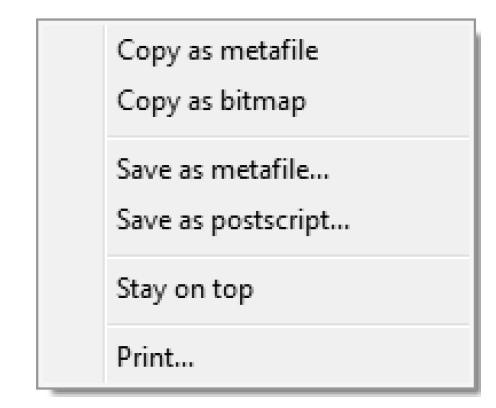

## 3.7.5 Using R commands to save graphs

```r
pdf("ZrBoxplot.pdf")
data(bottle.df)
boxplot(Zr ~ Number, data = bottle.df)
graphics.off()
```